# Antares new features v8.6.0

```r
 # CRAN limite CPU usage
data.table::setDTthreads(2)
library(antaresEditObject)
```

This thumbnail will present the new features in line with **Antares v8.6.0** (the link is [here](https://antares-simulator.readthedocs.io/en/stable/developer-guide/CHANGELOG/#branch-86x-end-of-support-062025))

There are 3 new features :

> - Add new storage type “short-term storage”.
> - Update parameters of thermal clusters with “pollutant emission factors”
> - “Hydro Pmin” : new file “mingen.txt”

## Create new study

```r
dir_path <- tempdir()
createStudy(path = dir_path,
            study_name = "test860",
            antares_version = "8.6.0")
```

## Create area

```r
createArea(name = "fr")
createArea(name = "it")
```

## Create “st-storage”

We can create new st-storage cluster with new function `createClusterST()`. You can see function documentation with `?createClusterST`.

By default you can call function only with two parameters (`area`, `cluster_name`).

```r
inflows_data <- matrix(3, 8760)
ratio_values <- matrix(0.7, 8760)

createClusterST(area = "fr",
                cluster_name = "test_storage",
                storage_parameters = storage_values_default(),
                PMAX_injection = ratio_values,
                PMAX_withdrawal = ratio_values,
                inflows = inflows_data,
                lower_rule_curve = ratio_values,
                upper_rule_curve = ratio_values,
                overwrite = TRUE)

createClusterST(area = "it",
                cluster_name = "test_storage",
                storage_parameters = storage_values_default(),
                PMAX_injection = ratio_values,
                PMAX_withdrawal = ratio_values,
                inflows = inflows_data,
                lower_rule_curve = ratio_values,
                upper_rule_curve = ratio_values,
                overwrite = TRUE)
```

Now you can see informations in simulation options.

```r
opts <- simOptions()
opts$areasWithSTClusters
```

```
#> [1] "fr" "it"
```

## Read st-storages parameters

After creating “st-storage” clusters, you can read all information with specific function `readClusterSTDesc()`.

```r
tab <- readClusterSTDesc()
rmarkdown::paged_table(tab)
```

| area | cluster | group | efficiency | initiallevel | initialleveloptim | injectionnominalcapacity | reservoircapacity | withdrawalnominalcapacity |
| --- | --- | --- | --- | --- | --- | --- | --- | --- |
| fr | fr_test_storage | Other1 | 1 | 0 | FALSE | 0 | 0 | 0 |
| it | it_test_storage | Other1 | 1 | 0 | FALSE | 0 | 0 | 0 |

## Read st-storages data

St-storages data are time series you can read for all areas or a specific area. 5 files contening one time series are generated (one per each function parameter):

- PMAX-injection.txt
- PMAX-withdrawal.txt
- inflows.txt
- lower-rule-curve.txt
- upper-rule-curve.txt

```r
data_st_storage <- readInputTS(st_storage = "all")
```

```
#> Importing st-storage
#>   |                                                                              |                                                                      |   0%  |                                                                              |===================================                      …
```

```r
rmarkdown::paged_table(head(data_st_storage))
```

| area | cluster | timeId | time | day | month | hour | tsId | st-storage | name_file |
| --- | --- | --- | --- | --- | --- | --- | --- | --- | --- |
| fr | fr_test_storage | 1 | 2018-01-01 00:00:00 | 1 | JAN | 00:00 | 1 | 0.7 | PMAX-injection |
| fr | fr_test_storage | 2 | 2018-01-01 01:00:00 | 1 | JAN | 01:00 | 1 | 0.7 | PMAX-injection |
| fr | fr_test_storage | 3 | 2018-01-01 02:00:00 | 1 | JAN | 02:00 | 1 | 0.7 | PMAX-injection |
| fr | fr_test_storage | 4 | 2018-01-01 03:00:00 | 1 | JAN | 03:00 | 1 | 0.7 | PMAX-injection |
| fr | fr_test_storage | 5 | 2018-01-01 04:00:00 | 1 | JAN | 04:00 | 1 | 0.7 | PMAX-injection |
| fr | fr_test_storage | 6 | 2018-01-01 05:00:00 | 1 | JAN | 05:00 | 1 | 0.7 | PMAX-injection |

As you can see, the last two columns (`st-storage`, `name_file`) give you value for each name file.  
**FYI** : As default, reading option for hourly timestep is 8736 (see `opts$timeIdMax`).

## Edit st-storage

It is possible to edit parameters values and data values like you want.

```r
# edit parameters values
list_params_st <- storage_values_default()
list_params_st$efficiency <- 0.5
list_params_st$reservoircapacity <- 50

# edit data values
inflows_data <- matrix(4, 8760)

editClusterST(area = "fr",
              cluster_name = "test_storage",
              storage_parameters = list_params_st,
              inflows = inflows_data,
              add_prefix = TRUE)

# read parameters
tab <- readClusterSTDesc()
rmarkdown::paged_table(tab)
```

| area | cluster | group | efficiency | initiallevel | initialleveloptim | injectionnominalcapacity | reservoircapacity | withdrawalnominalcapacity |
| --- | --- | --- | --- | --- | --- | --- | --- | --- |
| fr | fr_test_storage | Other1 | 0.5 | 0 | FALSE | 0 | 50 | 0 |
| it | it_test_storage | Other1 | 1.0 | 0 | FALSE | 0 | 0 | 0 |

```r
# read data
data_st_storage <- readInputTS(st_storage = "all")
```

```
#> Importing st-storage
#>   |                                                                              |                                                                      |   0%  |                                                                              |===================================                      …
```

```r
rmarkdown::paged_table(head(data_st_storage))
```

| area | cluster | timeId | time | day | month | hour | tsId | st-storage | name_file |
| --- | --- | --- | --- | --- | --- | --- | --- | --- | --- |
| fr | fr_test_storage | 1 | 2018-01-01 00:00:00 | 1 | JAN | 00:00 | 1 | 0.7 | PMAX-injection |
| fr | fr_test_storage | 2 | 2018-01-01 01:00:00 | 1 | JAN | 01:00 | 1 | 0.7 | PMAX-injection |
| fr | fr_test_storage | 3 | 2018-01-01 02:00:00 | 1 | JAN | 02:00 | 1 | 0.7 | PMAX-injection |
| fr | fr_test_storage | 4 | 2018-01-01 03:00:00 | 1 | JAN | 03:00 | 1 | 0.7 | PMAX-injection |
| fr | fr_test_storage | 5 | 2018-01-01 04:00:00 | 1 | JAN | 04:00 | 1 | 0.7 | PMAX-injection |
| fr | fr_test_storage | 6 | 2018-01-01 05:00:00 | 1 | JAN | 05:00 | 1 | 0.7 | PMAX-injection |

## Remove st-storage

Creating or editing st-storage are done, you can also remove clusters from study.

```r
# remove cluster
removeClusterST(area = "fr",
                cluster_name = "test_storage",
                add_prefix = TRUE)

# delete control
opts <- simOptions()
opts$areasWithSTClusters
```

```
#> [1] "it"
```

The area `fr` is deleted cause we created only one cluster `test_storage`.

```r
# control removed parameters
tab <- readClusterSTDesc()
rmarkdown::paged_table(head(tab))
```

| area | cluster | group | efficiency | initiallevel | initialleveloptim | injectionnominalcapacity | reservoircapacity | withdrawalnominalcapacity |
| --- | --- | --- | --- | --- | --- | --- | --- | --- |
| it | it_test_storage | Other1 | 1 | 0 | FALSE | 0 | 0 | 0 |

```r
# control removed data
data_st_storage <- readInputTS(st_storage = "all")
```

```
#> Importing st-storage
#>   |                                                                              |                                                                      |   0%  |                                                                              |=========================================================…
```

```r
rmarkdown::paged_table(head(data_st_storage))
```

| area | cluster | timeId | time | day | month | hour | tsId | st-storage | name_file |
| --- | --- | --- | --- | --- | --- | --- | --- | --- | --- |
| it | it_test_storage | 1 | 2018-01-01 00:00:00 | 1 | JAN | 00:00 | 1 | 0.7 | PMAX-injection |
| it | it_test_storage | 2 | 2018-01-01 01:00:00 | 1 | JAN | 01:00 | 1 | 0.7 | PMAX-injection |
| it | it_test_storage | 3 | 2018-01-01 02:00:00 | 1 | JAN | 02:00 | 1 | 0.7 | PMAX-injection |
| it | it_test_storage | 4 | 2018-01-01 03:00:00 | 1 | JAN | 03:00 | 1 | 0.7 | PMAX-injection |
| it | it_test_storage | 5 | 2018-01-01 04:00:00 | 1 | JAN | 04:00 | 1 | 0.7 | PMAX-injection |
| it | it_test_storage | 6 | 2018-01-01 05:00:00 | 1 | JAN | 05:00 | 1 | 0.7 | PMAX-injection |

```r
unique(data_st_storage$area)
```

```
#> [1] "it"
```

Parameters and data concerning this cluster in this area are removed.

## Thermal pollutants parameters

Antares version 8.6.0 now provide pollutants parameters for thermal clusters. You can see the documentation on thermal clusters [here](https://rte-antares-rpackage.github.io/antaresEditObject/articles/antaresEditObject.html#create-a-new-cluster).

You have global `list` of pollutants given by function `list_pollutants_values()`. By default, parameters are set to NULL, you can initialize all parameters with value or customize parameters.

```r
# create cluster with pollutants

# pollutants
all_param_pollutants <- list_pollutants_values(multi_values = 0.25)

createCluster(area = "fr",
              cluster_name = "test_pollutant",
              unitcount = 1L,
              marginal_cost = 50,
              list_pollutants = all_param_pollutants,
              time_series = matrix(rep(c(0, 8000), each = 24*364), ncol = 2),
              prepro_modulation = matrix(rep(c(1, 1, 1, 0), each = 24*365), ncol = 4)
              )
```

```r
# read parameters
param_th_cluster <- readClusterDesc()
rmarkdown::paged_table(param_th_cluster)
```

| area | cluster | group | co2 | enabled | fixed.cost | gen.ts | law.forced | law.planned | marginal.cost | market.bid.cost | min.down.time | min.stable.power | min.up.time | must.run | nh3 | nmvoc | nominalcapacity | nox | op1 | op2 | op3 | op4 | op5 | pm10 | pm2_5 | pm5 | so2 | spinning | spread.cost | … |
| --- | --- | --- | --- | --- | --- | --- | --- | --- | --- | --- | --- | --- | --- | --- | --- | --- | --- | --- | --- | --- | --- | --- | --- | --- | --- | --- | --- | --- | --- | --- |
| fr | fr_test_pollutant | Other | 0.25 | TRUE | 0 | Use Global | Uniform | Uniform | 50 | 0 | 1 | 0 | 1 | FALSE | 0.25 | 0.25 | 0 | 0.25 | 0.25 | 0.25 | 0.25 | 0.25 | 0.25 | 0.25 | 0.25 | 0.25 | 0.25 | 0 | 0 | … |

Let’s see how to edit 3 parameters **nh3, nox, pm2_5**.

```r
# editing
edit_param_pollutants <- list_pollutants_values(multi_values = 0.3)[1:3]

editCluster(area = "fr",
            cluster_name = "test_pollutant",
            unitcount = 2L,
            list_pollutants = edit_param_pollutants)

# read parameters
param_th_cluster <- readClusterDesc()
rmarkdown::paged_table(param_th_cluster)
```

| area | cluster | group | co2 | enabled | fixed.cost | gen.ts | law.forced | law.planned | marginal.cost | market.bid.cost | min.down.time | min.stable.power | min.up.time | must.run | nh3 | nmvoc | nominalcapacity | nox | op1 | op2 | op3 | op4 | op5 | pm10 | pm2_5 | pm5 | so2 | spinning | spread.cost | … |
| --- | --- | --- | --- | --- | --- | --- | --- | --- | --- | --- | --- | --- | --- | --- | --- | --- | --- | --- | --- | --- | --- | --- | --- | --- | --- | --- | --- | --- | --- | --- |
| fr | fr_test_pollutant | Other | 0.25 | TRUE | 0 | Use Global | Uniform | Uniform | 50 | 0 | 1 | 0 | 1 | FALSE | 0.3 | 0.25 | 0 | 0.3 | 0.25 | 0.25 | 0.25 | 0.25 | 0.25 | 0.25 | 0.3 | 0.25 | 0.25 | 0 | 0 | … |

## Hydro - MINGEN file

Antares version 8.6.0 provides new file `mingen.txt`, this file must respect some conditions.  
The first condition to respect is the dimension with file `mod.txt`.  
The second one is the consistency of the data between 3 files (`mingen.txt`, `mod.txt`, `maxpower_{area}.txt`).

Full documentation is available in the function `writeInputTS()`. We will see further information for values checks.

**Values checks :**

Checks depends of values of parameters in `hydro.ini` file.

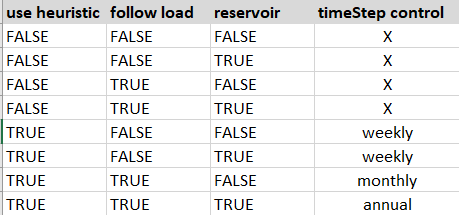

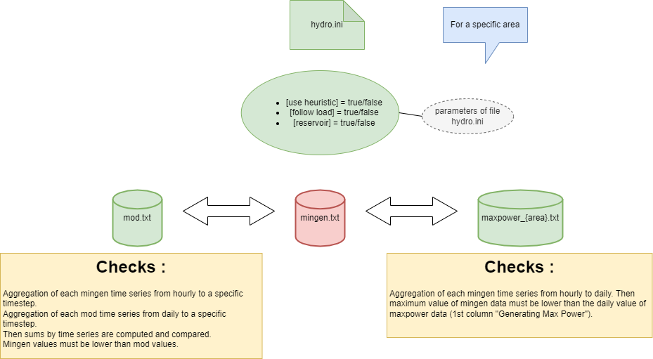

After creating study, `.txt` files containing time series are empty. We will describe steps to edit `mingen.txt`.

**Initial values :**

```r
# see hydro parameters
path_file_hydro <- file.path("input", "hydro", "hydro.ini")
hydro_ini_values <- readIni(pathIni = path_file_hydro)
hydro_params <- c('follow load', 'use heuristic', "reservoir")
hydro_ini_values[hydro_params]
```

```
#> $`follow load`
#> $`follow load`$fr
#> [1] TRUE
#>
#> $`follow load`$it
#> [1] TRUE
#>
#>
#> $`use heuristic`
#> $`use heuristic`$fr
#> [1] TRUE
#>
#> $`use heuristic`$it
#> [1] TRUE
#>
#>
#> $reservoir
#> $reservoir$fr
#> [1] FALSE
#>
#> $reservoir$it
#> [1] FALSE
```

**Steps to create mingen file :**

```r
# Initialize mingen data (time series)
mingen_data = matrix(0.06,8760,5)

# 1 - edit mod file (time series)
mod_data = matrix(6,365,5)
suppressWarnings(
  writeInputTS(area = "fr", type = "hydroSTOR",
             data = mod_data,
             overwrite = TRUE)
)
```

```
#> Importing mingen
#>   |                                                                              |                                                                      |   0%  |                                                                              |=========================================================…
#> Importing hydroStorage
#>   |                                                                              |                                                                      |   0%  |                                                                              |=========================================================…
```

```r
# 2 - edit maxpower
maxpower_data <- matrix(6,365,4)
suppressWarnings(
  writeHydroValues(area = "fr",
                 type = "maxpower",
                 data = maxpower_data)
)
```

```
#> conversion automatique de classe pour x : matrix vers data.table
#> Importing mingen
#>   |                                                                              |                                                                      |   0%  |                                                                              |=========================================================…
#> Importing hydroStorageMaxPower
#>   |                                                                              |                                                                      |   0%  |                                                                              |=========================================================…
```

```r
# 3 - edit mingen
suppressWarnings(
  writeInputTS(area = "fr", type = "mingen",
             data = mingen_data,
             overwrite = TRUE)
)
```

```
#> Importing mingen
#>   |                                                                              |                                                                      |   0%  |                                                                              |=========================================================…
#> Importing hydroStorage
#>   |                                                                              |                                                                      |   0%  |                                                                              |=========================================================…
#> Importing mingen
#>   |                                                                              |                                                                      |   0%  |                                                                              |=========================================================…
#> Importing hydroStorageMaxPower
#>   |                                                                              |                                                                      |   0%  |                                                                              |=========================================================…
```

Now we can read time series.

```r
# read input time series
read_ts_file <- readInputTS(mingen = "all")
```

```
#> Importing mingen
#>   |                                                                              |                                                                      |   0%  |                                                                              |===================================                      …
```

```r
rmarkdown::paged_table(head(read_ts_file))
```

| area | timeId | time | day | month | hour | tsId | mingen |
| --- | --- | --- | --- | --- | --- | --- | --- |
| fr | 1 | 2018-01-01 00:00:00 | 1 | JAN | 00:00 | 1 | 0.06 |
| fr | 2 | 2018-01-01 01:00:00 | 1 | JAN | 01:00 | 1 | 0.06 |
| fr | 3 | 2018-01-01 02:00:00 | 1 | JAN | 02:00 | 1 | 0.06 |
| fr | 4 | 2018-01-01 03:00:00 | 1 | JAN | 03:00 | 1 | 0.06 |
| fr | 5 | 2018-01-01 04:00:00 | 1 | JAN | 04:00 | 1 | 0.06 |
| fr | 6 | 2018-01-01 05:00:00 | 1 | JAN | 05:00 | 1 | 0.06 |